# HW 13

### 14.7.5

Letting $\mu = \frac{a^2 \Delta t^2}{h^2}$ the difference method becomes

$$u_j^{(k+1)} = (2-2\mu)u_j^{(k)} + \mu u_{j-1}^{(k)} + \mu u_{j+1}^{(k)} - u_j^{(k-1)}$$

And so

$$u^{(k+1)} = Au^{(k)} - u^{(k-1)}$$

where $A$ is the tridiagonal matrix with diagonals $\mu, 2-2\mu, \mu.$

Code is below, written in Python 3 with numpy and matplotlib.

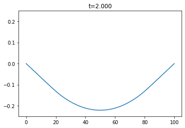

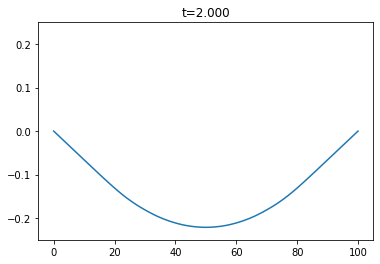

```python
import numpy as np
%matplotlib inline
import matplotlib.pyplot as plt
from IPython import display

def f(x):
    return x*(1-x)

def g(x):
    return 0

def test(n, dt, end_t=2, plot_every=50):
    h = 1/n
    x = np.arange(h, 1, h)
    u = f(x)
    u_prev = u

    a_squared = 2

    mu = a_squared * dt**2 * n**2

    A = np.zeros((n-1, n-1))
    for i in range(n-1):
        if i > 0:
            A[i, i-1] = mu
        if i < n-2:
            A[i, i+1] = mu
        A[i, i] = 2 - 2*mu

    def step(u, u_prev):
        return A @ u - u_prev

    hdisplay = display.display("", display_id=True)

    fig = plt.figure()
    ax = fig.add_subplot(111)
    graph, = ax.plot(np.concatenate([[0], u, [0]]))
    ax.set_ylim(-0.25, 0.25)


    for i in range(round(end_t/dt)+1):
        u, u_prev = step(u, u_prev), u

        if i%plot_every == 0: # plotting is slow, so only plot every few.
            graph.set_ydata(np.concatenate([[0], u, [0]]))
            ax.set_title("t=%.3f"%(i*dt))
            hdisplay.update(fig)

test(100, 0.001)
```

I'm not entirely sure why there's that second plot on the bottom, but the code works (it bounces up and down like a guitar string). Here's what happens if the stability requirement isn't met:

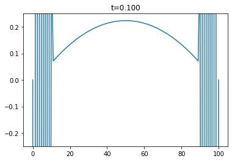

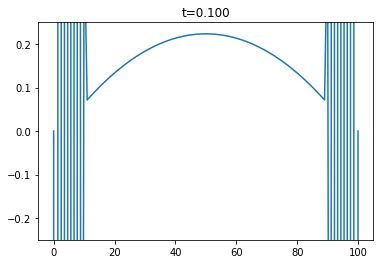

```python
test(100, 0.01, end_t=0.1, plot_every=10)
```

The wave quickly "breaks" apart.

### 14.7.6

I'll use the Fourier stability analysis. Assume that $$u_j^{(k)} = \sum g_{\xi}^k e^{ijh\xi}.$$

If $|g| < 1$ for all frequencies $\xi$ then it will be stable. Looking at just one frequency, and plugging it into the Lax-Friedrichs difference method, we see that

$$g^k e^{ijh\xi}\left[g - \frac{a\lambda - 1}2\left(e^{-ih\xi} + e^{ih\xi}\right)\right] = 0$$

Or,

$$g = (a\lambda - 1)\cdot \frac{e^{-ih\xi} + e^{ih\xi}}{2} = (a\lambda - 1)\cos(h\xi)$$

Therefore we need $|a\lambda - 1| < 1\implies \lambda\in \left(0, \frac2a\right)$

### 12.3.2

Consider the polynomial

$$\det(A -\lambda I) = 0$$

The roots of this polynomial are the eigenvalues of $A$. However, as $A$ is real, the coefficients of this polynomial are also real. It is well known that a polynomial with real coefficients can only have complex roots if they come in conjugate pairs (i.e. if $x\in \mathbb{C}$ is a root, then so is $\overline{x}$, it's complex conjugate)*.

Therefore, any complex eigenvalue of $A$ has at least one other eigenvalue with the same magnitude, and there can't be a strict inequality $|\lambda_1| > |\lambda_2|$.

* Notice that $$\overline{xy} = \overline{x}\cdot \overline{y}$$ and $$\overline{x+y} = \overline{x} + \overline{y}$$ therefore if $$p(x) = a_0 + a_1x + a_2x^2 + \cdots$$ then $$p(\overline{x}) = a_0 + a_1\overline{x} + a_2\overline{x}^2 + \cdots = \overline{a_0 + a_1x + a_2x^2 + \cdots} = \overline{p(x)}.$$

Then if $p(x) = 0,$ $$p(\overline{x}) = \overline{p(x)} = 0$$ also.

### 12.3.3

Take the shift $\mu = \lambda_1$ so that the shifted eigenvalues are

$$2\lambda_1, 0, \lambda_3+\lambda_1, \lambda_4+\lambda_1\dots.$$

By the triangle inequality, $$|\lambda_k + \lambda_1| \le |\lambda_k| + \lambda_1 < \lambda_1 + \lambda_1=2\lambda_1,$$

so the largest eigenvalue has strictly larger magnitude than all the other eigenvalues.

### 12.3.5

**(a)** Gerschgorin's theorem implies that all of the eigenvalues lie within a disc of radius $2$ centered at $2$ (equivalent to $|\lambda - 2| \le 2$).

**(b)**

```python
A = np.diag(np.ones(10), 0)*2 - np.diag(np.ones(9), 1) - np.diag(np.ones(9), -1)

def step(A, v):
    w = A @ v

    return w/np.linalg.norm(w), np.dot(v, w)

v = np.random.random(10)
ls = []
for i in range(10000):
    v, l = step(A, v)
    ls.append(l)

print(f"lambda =  {l}")
```

```
lambda =  3.9189859472289945
```

```
Stabilizes at about r=0.8829419465149208
```

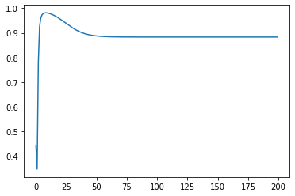

```python
import warnings
warnings.filterwarnings('ignore')

# check convergence
errors = abs(np.array(ls) - l)
ratios = errors[1:]/errors[:-1]
plt.plot(ratios[0:200])
print(f"Stabilizes at about r={ratios[200]}")
```

The error rate is exponential after a few iterations, with a common ratio of about $0.88$. The eigenvalue it finds is $\lambda = 3.919.$

**(c)**

```python
A = np.diag(np.ones(10), 0)*2 - np.diag(np.ones(9), 1) - np.diag(np.ones(9), -1)

q, r = np.linalg.qr(A)
new_A = r @ q

errors = []

while np.amax(abs(new_A - A)) > 1e-15:
    off_diag = np.diag(np.ones(9), -1) * A
    errors.append(np.amax(abs(off_diag)))

    A = new_A
    q, r = np.linalg.qr(A)
    new_A = r @ q

eigs = np.array([new_A[i, i] for i in range(10)])
print(np.matrix.round(new_A, 3))
print("Eigenvalues:")
print(eigs)
```

```
[[ 3.919 -0.     0.     0.     0.    -0.    -0.    -0.     0.    -0.   ]
 [-0.     3.683 -0.    -0.    -0.     0.    -0.     0.    -0.    -0.   ]
 [ 0.    -0.     3.31  -0.    -0.     0.     0.     0.    -0.     0.   ]
 [ 0.     0.    -0.     2.831 -0.    -0.    -0.     0.     0.    -0.   ]
 [ 0.     0.     0.    -0.     2.285 -0.    -0.    -0.     0.    -0.   ]
 [ 0.     0.     0.     0.    -0.     1.715  0.    -0.    -0.    -0.   ]
 [ 0.     0.     0.     0.     0.    -0.     1.169  0.     0.     0.   ]
 [ 0.     0.     0.     0.     0.     0.    -0.     0.69   0.    -0.   ]
 [ 0.     0.     0.     0.     0.     0.     0.    -0.     0.317 -0.   ]
 [ 0.     0.     0.     0.     0.     0.     0.     0.     0.     0.081]]
Eigenvalues:
[3.91898595 3.68250707 3.30972147 2.83083003 2.28462968 1.71537032
 1.16916997 0.69027853 0.31749293 0.08101405]
```

```
0.939659734538806
```

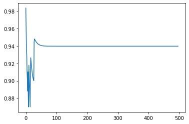

```python
errors = np.array(errors)
ratios = errors[1:]/errors[:-1]
plt.plot(ratios)
print(ratios[100])
```

The off diagonal entries converge to $0$ with a ratio of about $0.94$ (though it varies until about the 100th iteration). We get the eigenvalues listed above.

**(d)**

```python
shift = 2.9

A_shift = A - np.identity(10) * shift
A_shift_inv = np.linalg.inv(A_shift)


v = np.random.random(10)
for i in range(10000):
    v, l = step(A_shift_inv, v)

# Small entries should be 0, but sometimes they will output as -0 if
# I don't set them to 0.
v[abs(v) < 1e-5] = 0

print("Eigenvalue:")
print(1/l + shift)
print("Eigenvector:")
print(np.round(v, 5))
```

```
Eigenvalue:
2.8308300260037664
Eigenvector:
[0. 0. 0. 1. 0. 0. 0. 0. 0. 0.]
```

Using a shift of $2.9$, it should find the eigenvalue $2.83$, and it does. The corresponding eigenvector is $[0\ 0\ 0\ 1\ 0\ 0\ 0\ 0\ 0\ 0]^T$.